# Amazon Wine Making Business

Study group 10: Ben Spertus, Emil Erne, Jing Zhou, Salome Corcos, Shengjie Shi, Vaani Rawat

2023-11-20

# Loading and Cleaning Data

```r
# Load required libraries
library(vroom)  # for fast data import
library(dplyr)  # for data manipulation

# Load and clean the wine production dataset
wine_production <- vroom('/Users/vaanirawat/Desktop/Wine Dataset/UNdata_Export_20231119_114926894.csv') %>%
  clean_names() %>%  # Converts all column names to lowercase and replaces spaces with underscores
  select(-value_footnotes)  # Removes the 'value_footnotes' column from the dataset
# Extract unique country or area names from the dataset
unique_names <- unique(wine_production$country_or_area)
# Get a summary glimpse of the wine production dataset
glimpse(wine_production)
```

```
## Rows: 4,834
## Columns: 5
## $ country_or_area <chr> "Africa", "Africa", "Africa", "Africa", "Africa", "Afr…
## $ element         <chr> "Production", "Production", "Production", "Production"…
## $ year            <dbl> 2019, 2018, 2017, 2016, 2015, 2014, 2013, 2012, 2011, …
## $ unit            <chr> "tonnes", "tonnes", "tonnes", "tonnes", "tonnes", "ton…
## $ value           <dbl> 1092651, 1062215, 1190381, 1139255, 1220562, 1238673, …
```

```r
# Load and clean the wine consumption data
wine_consumption <- vroom('/Users/vaanirawat/Desktop/Wine Dataset/wine-consumption-per-person (1).csv') %>%
  clean_names()  # Converts all column names to lowercase and replaces spaces with underscores
# Rename columns to more understandable names
wine_consumption <- rename(
  wine_consumption,
  wine_consumption = indicator_alcohol_recorded_per_capita_15_consumption_in_litres_of_pure_alcohol_beverage_types_wine
)  # Renames a lengthy column name to 'wine_consumption'

wine_consumption <- rename(
  wine_consumption,
  Country = entity
)  # Renames the 'entity' column to 'Country'

# Standardize Country Names
wine_consumption <- wine_consumption %>%
  mutate(
    Country = countrycode(
      Country,
      origin = 'country.name',
      destination = 'country.name'
    )
  )
  # Standardizes country names using the countrycode package.
  # Converts any variation of country names to a standard format.
```

```r
#calculate production by region in 2019
#create df to do production calc by region

wine_data_summary <- wine_production %>%
 mutate(country_or_area = countrycode(country_or_area, origin= 'country.name',
                       destination = 'country.name'
                       ))
# Get a vector of all valid country names
valid_countries <- countrycode::codelist$country.name.en

# Filter ata to only include rows where country_or_area is a valid country name
wine_data_summary <- wine_data_summary %>%
  filter(country_or_area %in% valid_countries) %>%
  filter(year == 2019) %>%
  group_by(country_or_area) %>%
  summarize(country_or_area,Total = sum(value))
glimpse(wine_data_summary)
```

```
## Rows: 61
## Columns: 2
## Groups: country_or_area [60]
## $ country_or_area <chr> "Albania", "Algeria", "Argentina", "Armenia", "Austral…
## $ Total           <dbl> 15925, 20830, 1301947, 12750, 1197000, 8773, 33970, 70…
```

# Production and Consumption Visualisations Worldwide

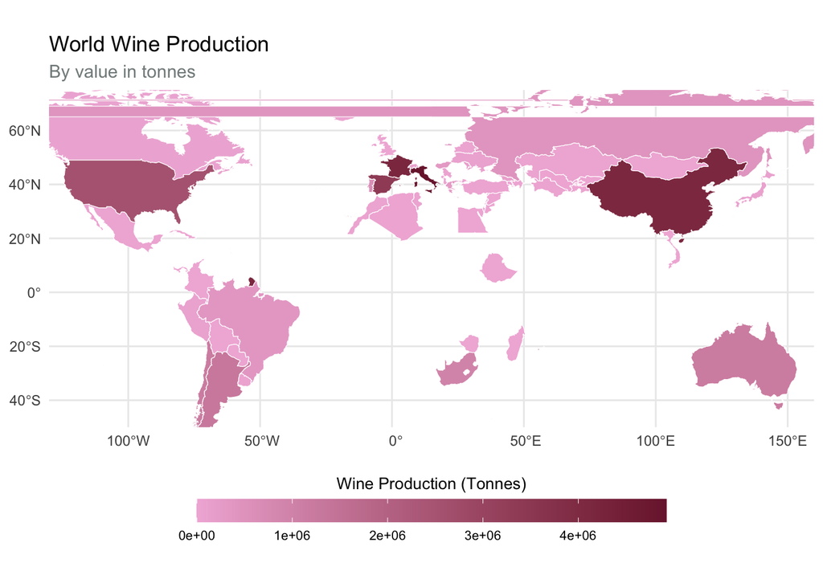

```r
# Get the world map
world <- ne_countries(scale = "medium", returnclass = "sf")

# Attempt to correct invalid geometries
world$geometry <- st_make_valid(world$geometry)

# Join data with world map
world_wine <- left_join(world, wine_data_summary, by = c("name" = "country_or_area"))

# Filter out NAs
world_wine <- world_wine %>% filter(!is.na(Total))

# Plot map with heatmap for wine production
ggplot(data = world_wine) +
  geom_sf(aes(fill = Total), color = "white") +
  scale_fill_gradient(low = "#F1B6DA", high = "#7B1F3A", na.value = "lightgray",
                      guide = guide_colourbar(title.position = "top",
                                              title.hjust = 0.5,
                                              barwidth = 20,
                                              barheight = 1,
                                              nbin = 500,
                                              label.position = "bottom")) +
  coord_sf(xlim = c(-130, 160), ylim = c(-50, 75), expand = FALSE) +
  theme_minimal() +
  theme(legend.position = "bottom",
        legend.text = element_text(size = 8),
        legend.title = element_text(size = 10),
        plot.subtitle = element_text(color = "azure4")) +
  labs(fill = "Wine Production (Tonnes)",
       title = "World Wine Production",
       subtitle = "By value in tonnes")
```

```r
# Assuming wine_data_summary has columns 'country_or_area' and 'Total'
top_5_wine_producing_countries <- wine_data_summary %>%
    arrange(desc(Total)) %>%
    select(country_or_area, Total) %>%
  unique()%>%
  head(5)

# Print the top 5 countries
print(top_5_wine_producing_countries)
```

```
## # A tibble: 5 × 2
## # Groups:   country_or_area [5]
##   country_or_area   Total
##   <chr>             <dbl>
## 1 Italy           4922500
## 2 France          4165524
## 3 China           4131122
## 4 Spain           3370000
## 5 United States   2583429
```

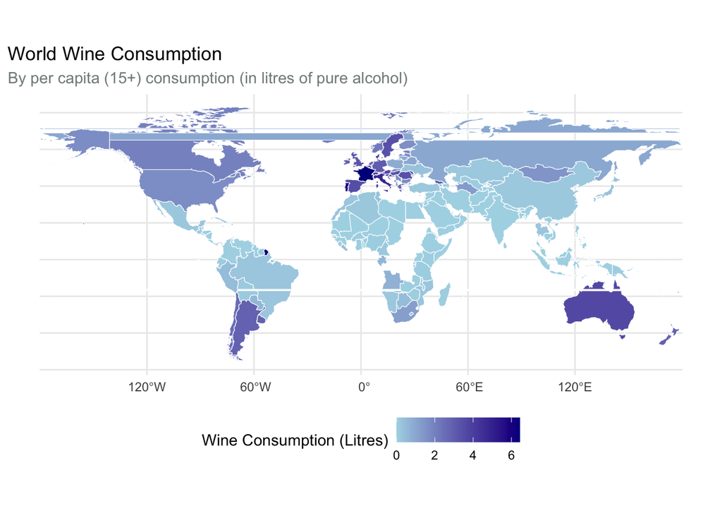

```r
# Calculate summary table wine consumption 2019
wine_consumption_summary <- wine_consumption %>%
  filter(year == 2019) %>%
  group_by(Country) %>%
  summarize(Total = sum(wine_consumption))

# Use prior centroid calculation and join consumption
world_consumption <- left_join(world, wine_consumption_summary, by = c("name" = "Country"))

# Filter out NAs
world_consumption <- world_consumption %>% filter(!is.na(Total))

# Plot map with heatmap for wine consumption
ggplot(data = world_consumption) +
  geom_sf(aes(fill = Total), color = "white") +
  scale_fill_gradient(low = "light blue", high = "dark blue", na.value = "lightgray") +
  theme_minimal() +
  theme(legend.position = "bottom",
        plot.subtitle = element_text(color = "azure4")) +
  labs(fill = "Wine Consumption (Litres)",
       title = "World Wine Consumption",
       subtitle = "By per capita (15+) consumption (in litres of pure alcohol)")
```

```r
# Assuming wine_consumption_summary has columns 'Country' and 'Total'
top_5_wine_consuming_countries <- wine_consumption_summary %>%
    arrange(desc(Total)) %>%
    slice_max(order_by = Total, n = 5) %>%
    select(Country, Total)

# Print the top 5 countries
print(top_5_wine_consuming_countries)
```

```
## # A tibble: 5 × 2
##   Country  Total
##   <chr>    <dbl>
## 1 France    6.44
## 2 Portugal  6.04
## 3 Slovenia  5.26
## 4 Andorra   4.98
## 5 Italy     4.83
```

The observation that the top five wine-consuming countries are in Europe, and three of the top five wine-producing countries are also European, highlights the significance of Europe in the global wine industry. This makes Europe a strategic focus area for setting up a wine-making business.

# Analysing European Market

## Historic and Forecasted Revenue

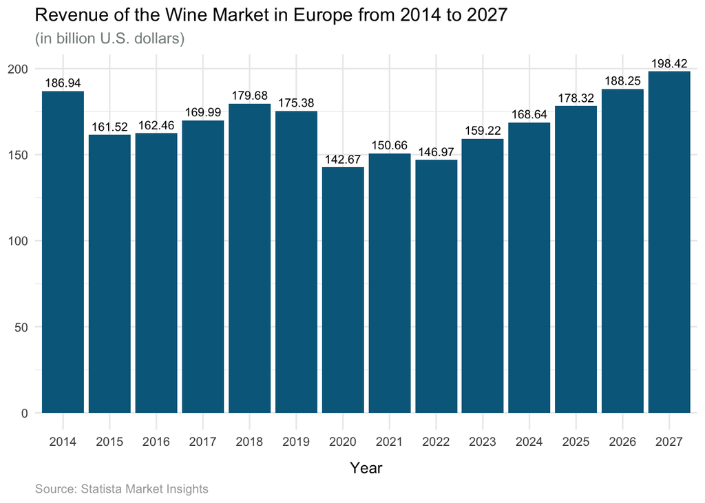

```r
# Read the Excel file containing European wine market data
european_market <- read_xlsx("european wine.xlsx")

# Create a bar graph using ggplot
ggplot(european_market, aes(x = Year, y = `Revenue of the wine market in Europe from 2014 to 2027 (in billion U.S. dollars)`)) +
  geom_bar(stat = "identity", fill = "deepskyblue4") +  # Creates bars with 'deepskyblue4' color
  geom_text(
    aes(label = round(`Revenue of the wine market in Europe from 2014 to 2027 (in billion U.S. dollars)`, 2)),
    vjust = -0.5,  # Positions the labels above the bars
    size = 3,
    color = "black"  # Sets the label text color to black
  ) +
  theme_minimal() +  # Applies a minimal theme to the plot
  theme(
    axis.text.y = element_text(angle = 0, hjust = 1),
    axis.title.y = element_blank(),
    axis.title.x = element_text(margin = margin(t = 10, b = 0)),  # Shifts the x-axis title down
    plot.caption = element_text(hjust = 0, color = "darkgrey"),
    plot.subtitle = element_text(color = "azure4")
  ) +
  labs(
    title = "Revenue of the Wine Market in Europe from 2014 to 2027",  # Sets the plot title
    subtitle = "(in billion U.S. dollars)",  # Sets the subtitle
    x = "Year",  # Labels the x-axis
    y = "Revenue (in billion U.S. dollars)",  # Labels the y-axis
    caption = "Source: Statista Market Insights"  # Sets the plot caption
  )
```

## Volume of Exported European Wine in 2022

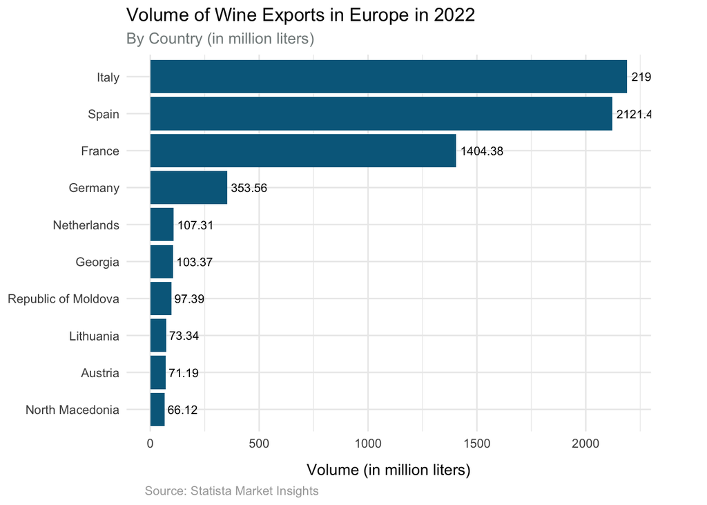

```r
# Read in the data from an Excel file
european_exports <- read_xlsx("europe exports.xlsx")

# Create a horizontal bar chart using ggplot
ggplot(european_exports, aes(y = reorder(Country, `Volume of wine exports in Europe in 2022, by country (in million liters)`),
                             x = `Volume of wine exports in Europe in 2022, by country (in million liters)`)) +
  geom_bar(stat = "identity", fill = "deepskyblue4") +  # Bar plot with bars filled in deep sky blue color
  geom_text(aes(label = round(`Volume of wine exports in Europe in 2022, by country (in million liters)`, 2)),
            hjust = -0.1, # Positions the labels to the right of the bar
            size = 3,
            color = "black") +  # Adds text labels with the rounded volume values
  theme_minimal() +  # Applies a minimalistic theme to the plot
  theme(
    plot.margin = margin(5.5, 40, 5.5, 5.5), # Customizes plot margins
    axis.text.y = element_text(angle = 0, hjust = 1),  # Adjusts the y-axis text to be horizontal
    axis.title.y = element_blank(),  # Removes the y-axis title
    axis.title.x = element_text(margin = margin(t = 10, b = 0)),  # Shifts the x-axis title down
    plot.caption = element_text(hjust = 0.052, color = "darkgrey"),
    plot.subtitle = element_text(color = "azure4")# Customizes the caption
  ) +
  labs(
    title = "Volume of Wine Exports in Europe in 2022",  # Sets the title of the plot
    subtitle = "By Country (in million liters)",  # Sets the subtitle
    x = "Volume (in million liters)",  # Labels the x-axis
    y = "Country",  # Labels the y-axis
    caption = "Source: Statista Market Insights"  # Sets the plot caption
  )
```

## Value of Exported Wine in 2022

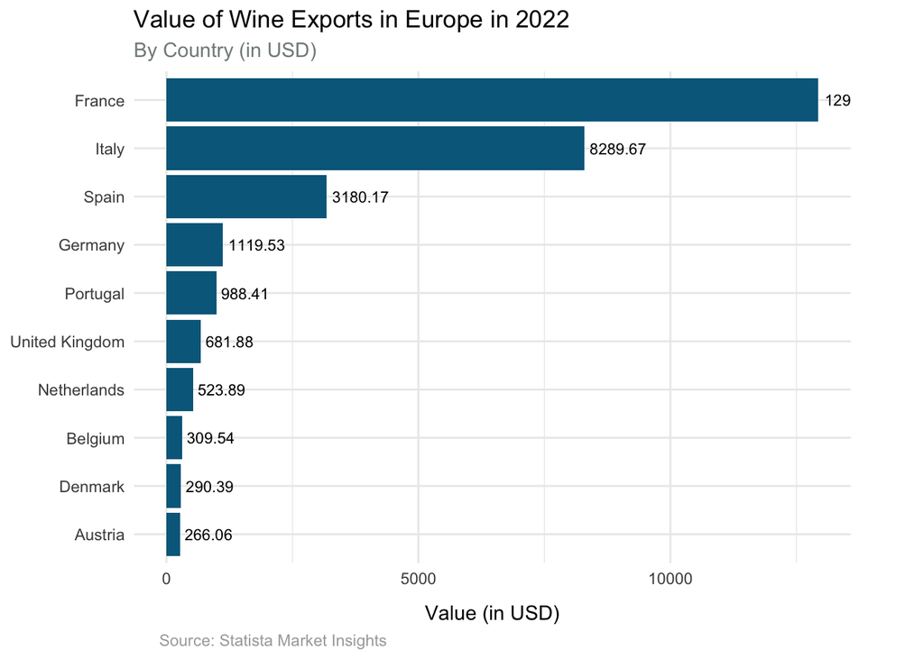

```r
# Read in the data from an Excel file
european_exports_value <- read_xlsx("value of wine exports.xlsx")

# Create a horizontal bar chart using ggplot
ggplot(european_exports_value, aes(y = reorder(Country, `Value of wine exports in Europe in 2022, by country (in million U.S. dollars)`),
                             x = `Value of wine exports in Europe in 2022, by country (in million U.S. dollars)`)) +
  geom_bar(stat = "identity", fill = "deepskyblue4") +  # Creates horizontal bars with a deep sky blue color
  geom_text(aes(label = round(`Value of wine exports in Europe in 2022, by country (in million U.S. dollars)`, 2)),
            hjust = -0.1, # Adjusts the position of the label to the right side of the bar
            size = 3,
            color = "black") +  # Adds text labels to the bars, showing the export value
  theme_minimal() +  # Applies a minimalistic theme to the plot for a clean look
  theme(
    plot.margin = margin(5.5, 40, 5.5, 5.5), # Customizes the plot margins for better layout
    axis.text.y = element_text(angle = 0, hjust = 1),  # Makes y-axis labels horizontal
    axis.title.y = element_blank(),  # Removes the y-axis title for a cleaner look
    axis.title.x = element_text(margin = margin(t = 10, b = 0)),  # Moves the x-axis title down for better spacing
    plot.caption = element_text(hjust = 0.052, color = "darkgrey"),
    plot.subtitle = element_text(color = "azure4")# Customizes the caption with a grey color and specific alignment
  ) +
  labs(
    title = "Value of Wine Exports in Europe in 2022",  # Sets the plot title
    subtitle = "By Country (in USD)",  # Sets the plot subtitle
    x = "Value (in USD)",  # Labels the x-axis
    y = "Country",  # Labels the y-axis
    caption = "Source: Statista Market Insights"  # Sets the plot caption
  )
```

The forecasted revenue trends in the European wine market are showing a pattern of growth, indicating a promising landscape for establishing a wine-making business. This positive outlook is further supported by trade data, which reveals that Italy, France, and Spain are leading in terms of both the volume of wine trade and the revenue generated from it. These countries, renowned for their rich wine-making heritage, not only dominate the European market but also have significant global influence in the wine industry.

# Product Differentiation

## Quality Analysis

```r
# Loading & Cleaning the datasets
red_wine <- read_csv(file = "wineQualityReds.csv")
```

```
## ──────────────────────────────────────────────────────── Delimiter: "," dbl
## (13): ...1, fixed.acidity, volatile.acidity, citric.acid, residual.sugar...
```

```r
white_wine <- read_csv(file = "wineQualityWhites.csv")
```

```
## ──────────────────────────────────────────────────────── Delimiter: "," dbl
## (13): ...1, fixed.acidity, volatile.acidity, citric.acid, residual.sugar...
```

```r
red_wine <- red_wine %>% select(-...1)
white_wine <- white_wine %>% select(-...1)
```

### Factors in correlation with Red Wine Quality

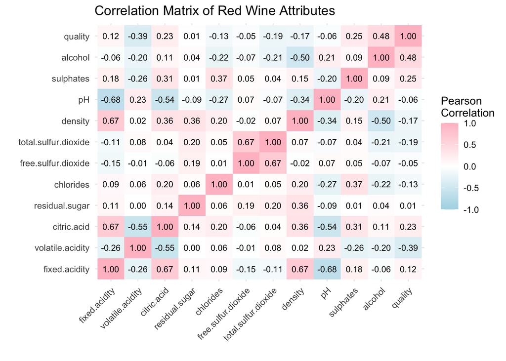

```r
# Calculating the correlation matrix
correlation_matrix <- cor(red_wine)

# Melting the correlation matrix for plotting
melted_correlation_matrix <- melt(correlation_matrix)

# Plotting the correlation matrix with lighter color scheme
ggplot(data = melted_correlation_matrix, aes(x=Var1, y=Var2, fill=value)) +
  geom_tile() +
  geom_text(aes(label=sprintf("%.2f", value)), color="black", size=3) +
  scale_fill_gradient2(low = "lightblue", high = "pink", mid = "white",
                       midpoint = 0, limit = c(-1,1), space = "Lab",
                       name="Pearson\nCorrelation") +
  theme_minimal() +
  theme(axis.text.x = element_text(angle = 45, vjust = 1, hjust = 1)) +
  labs(title = "Correlation Matrix of Red Wine Attributes", x = "", y = "")
```

The top factors most strongly correlated with red wine quality in this dataset are:

1. Alcohol (Correlation: 0.48)
2. Volatile Acidity (Correlation:-0.39)
3. Sulphates (Correlation: 0.25)
4. Citric Acid (Correlation: 0.23)

### Factors in correlation with White Wine Quality

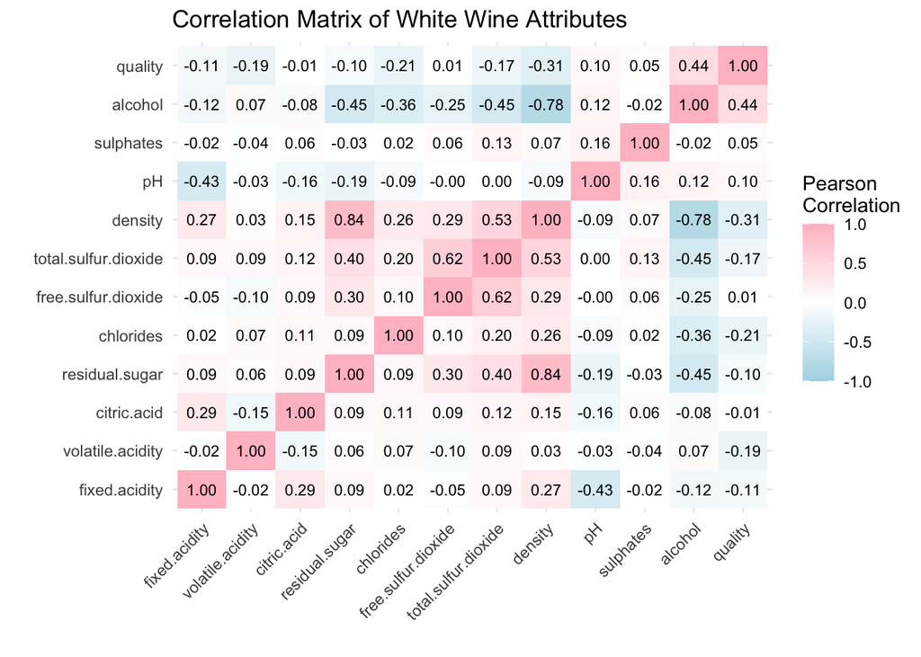

```r
# Calculating the correlation matrix
correlation_matrix <- cor(white_wine)

# Melting the correlation matrix for plotting
melted_correlation_matrix <- melt(correlation_matrix)

# Plotting the correlation matrix with lighter color scheme
ggplot(data = melted_correlation_matrix, aes(x=Var1, y=Var2, fill=value)) +
  geom_tile() +
  geom_text(aes(label=sprintf("%.2f", value)), color="black", size=3) +
  scale_fill_gradient2(low = "lightblue", high = "pink", mid = "white",
                       midpoint = 0, limit = c(-1,1), space = "Lab",
                       name="Pearson\nCorrelation") +
  theme_minimal() +
  theme(axis.text.x = element_text(angle = 45, vjust = 1, hjust = 1)) +
  labs(title = "Correlation Matrix of White Wine Attributes", x = "", y = "")
```

# Analysing E-commerce Alcohol Trends

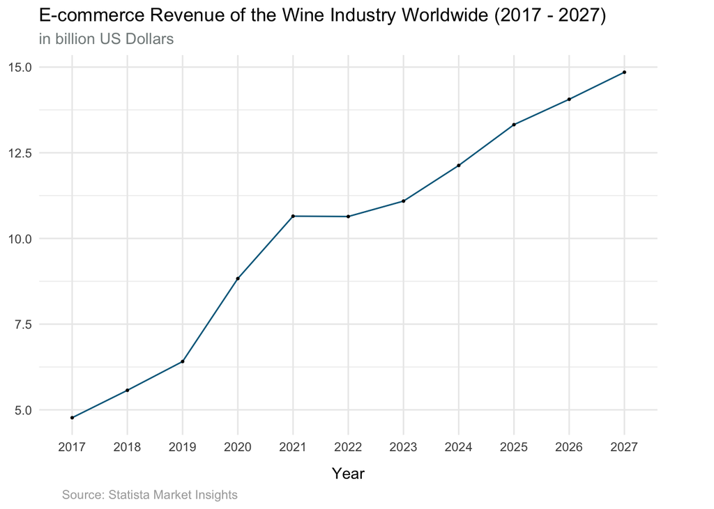

```r
ecommerce_wines <- read_xlsx("worldwide_ecommerce_wine.xlsx")
ggplot(ecommerce_wines, aes(x = Year, y = `E-commerce revenue of the wine industry worldwide from 2017 to 2027 (in billion U.S. dollars)`)) +
  geom_line(color = "deepskyblue4", group = 1) +  # Adding 'group = 1' ensures that ggplot knows how to connect the points
  geom_point(size = 0.5) +
  theme_minimal() +
  theme(
    plot.margin = margin(5.5, 40, 5.5, 5.5), # Customizes plot margins
    axis.text.y = element_text(angle = 0, hjust = 1),  # Adjusts the y-axis text to be horizontal
    axis.title.y = element_blank(),  # Removes the y-axis title
    axis.title.x = element_text(margin = margin(t = 10, b = 0)),  # Shifts the x-axis title down
    plot.caption = element_text(hjust = 0.052, color = "darkgrey"),
    plot.subtitle = element_text(color = "azure4")# Customizes the caption
  )+
  labs(
    title = "E-commerce Revenue of the Wine Industry Worldwide (2017 - 2027)",
    subtitle = "in billion US Dollars",
    x = "Year",
    y = "Revenue (in billion U.S. dollars)",
    caption = "Source: Statista Market Insights"  # Sets the plot caption
  )
```

[figure not shown]

```r
ecommerce_alcohol <- read_xlsx("alcohol ecommerce revenue.xlsx")
ggplot(ecommerce_alcohol, aes(y = reorder(Country, `Alcohol e-commerce market revenue worldwide in 2023, by country (in billion U.S. dollars)`),
                             x = `Alcohol e-commerce market revenue worldwide in 2023, by country (in billion U.S. dollars)`)) +
  geom_bar(stat = "identity", fill = "#7B1F3A") +
  geom_text(aes(label = round(`Alcohol e-commerce market revenue worldwide in 2023, by country (in billion U.S. dollars)`, 2)),
            hjust = -0.1, # Adjusts the position of the text to the right of the bar
            size = 3,
            color = "black") +
  theme_minimal() +
  theme(
    plot.margin = margin(5.5, 40, 5.5, 5.5), # Customizes plot margins
    axis.text.y = element_text(angle = 0, hjust = 1),  # Adjusts the y-axis text to be horizontal
    axis.title.y = element_blank(),  # Removes the y-axis title
    axis.title.x = element_text(margin = margin(t = 10, b = 0)),  # Shifts the x-axis title down
    plot.caption = element_text(hjust = 0.052, color = "darkgrey"),
    plot.subtitle = element_text(color = "azure4")# Customizes the caption
  ) +
  labs(
    title = "Vaule of Wine Exports in Europe in 2022",
    subtitle = "By country (in billion U.S. dollars)",
    x = "Value (in billion USD)",
    y = "Country",
    caption = "Source: Statista Market Insights"
  )
```

The rising trend in e-commerce for alcohol, with projections indicating continued growth, presents a significant opportunity. Amazon, with its robust e-commerce capabilities, is well-positioned to capitalize on this market. Notably, the highest e-commerce values for alcohol are seen in China, the US, Japan, the UK, and South Korea. This observation is intriguing, especially considering that while European countries are among the largest consumers and producers of wine, they lag in e-commerce sales for this category.

This gap in the European market represents a strategic opportunity for Amazon. By entering this relatively underserved e-commerce sector for wine in Europe, Amazon can leverage its established e-commerce strengths to create a niche. This move could be particularly impactful in creating product differentiation in highly competitive markets like the UK. By offering a unique and convenient online wine purchasing experience, Amazon can distinguish itself from local competitors and establish a strong foothold in the European market. The combination of Amazon’s e-commerce expertise and the rich wine heritage of Europe could be a recipe for success, tapping into new consumer segments and driving growth in the online alcohol sales sector.